# covid 19

Jason Briseno

10/12/2021

### Data is from the Patient_Info dataset from South Korea 1 Jan to 1 May

### This is contained in a downloadable zip file from kaggle

Some of the data was uncoded for sex - sex must be just male or female 77 of the data entries were coded sex as blank, so we omit these. state of a patient must be died or alive - we adjust that as well

# Question 1 - Is dying independent of sex

$H_0$: Dying is independent of sex.  
$H_A$: Dying is dependent of sex.

Table of patients:

```r
# cross tabulation, patient state by gender

with(kRdata, table(Sex, result))
```

```
##    result
## Sex alive dead
##   F  1831   25
##   M  1411   44
```

## We create two bar charts - one based on frequency and the other on percent, use ggplot commands to do this

```r
dd2 <- kRdata %>% group_by(result, Sex) %>% summarize(count=n()) %>% mutate(prcnt=count/sum(count))
```

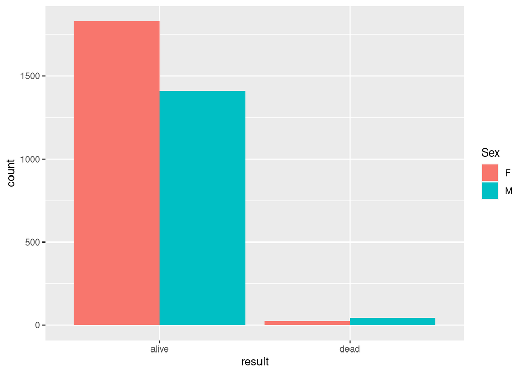

```r
# the group_by followed by summarize(count=n())

basicC <- ggplot(dd2,aes(x=result,y=count,fill=Sex))
basicC + geom_bar(stat="identity",position="dodge")
```

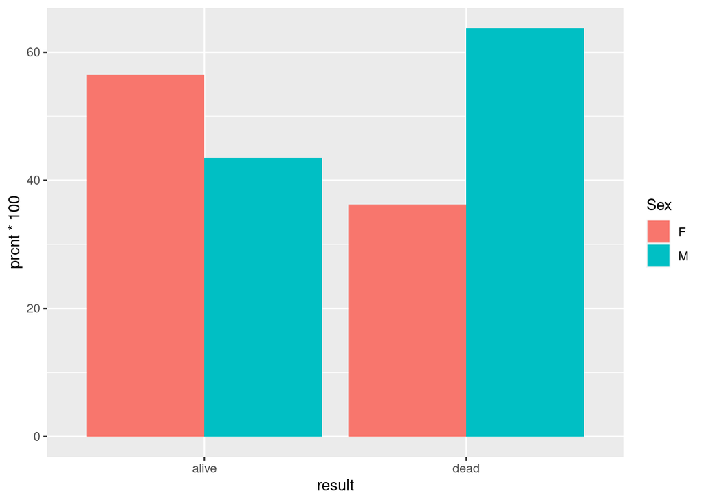

```r
#Now for percentage plot

basicCC <- ggplot(dd2,aes(x=result,y=prcnt*100,fill=Sex))
basicCC + geom_bar(stat="identity", position = "dodge")
```

## Numerical results

```r
table1 <- xtabs(~result + Sex, data=kRdata)
rowPerc(table1)
```

```
##        Sex
## result    F   M Total
##   alive  56  44   100
##   dead   36  64   100
```

```r
colPerc(table1)
```

```
##        Sex
## result      F   M
##   alive  98.7  97
##   dead    1.4   3
##   Total 100.0 100
```

Men died at almost twice the rate as women died from covid-19 in Korea. 36% of the dead were female and 64% were men.

Very few people died of covid, only 1.4% of females died, however 3% of men die, almost twice the rate than women.

## Inferential results

```r
chisq.test(table1)
```

```
##
##  Pearson's Chi-squared test with Yates' continuity correction
##
## data:  table1
## X-squared = 10, df = 1, p-value = 0.001
```

```r
chisqtestGC(table1)
```

```
## Pearson's Chi-squared test with Yates' continuity correction
##
## Observed Counts:
##        Sex
## result     F    M
##   alive 1831 1411
##   dead    25   44
##
## Counts Expected by Null:
##        Sex
## result     F    M
##   alive 1817 1425
##   dead    39   30
##
## Contributions to the chi-square statistic:
##        Sex
## result     F    M
##   alive 0.10 0.13
##   dead  4.84 6.17
##
##
## Chi-Square Statistic = 10
## Degrees of Freedom of the table = 1
## P-Value = 0.0012
```

```r
fisher.test(table1)
```

```
##
##  Fisher's Exact Test for Count Data
##
## data:  table1
## p-value = 9e-04
## alternative hypothesis: true odds ratio is not equal to 1
## 95 percent confidence interval:
##  1.4 3.9
## sample estimates:
## odds ratio
##        2.3
```

The P value = 0.001 is too low, thus we reject the null hypothesis. The death rate in Korea is dependent on sex.

The fisher exact tests shows that men died at 2.3 times the rate that women died.

## Conclusions

We reject the null hypothesis because the P value is too low.Men died at 2.3 times the rate that women did. We conclude that the death rate of South Koreans was dependant on sex.